# Simple Linear Regression

相关性是简单线性回归它爹，回归的概念来自于Francis Galton，他发现高个子男人生出来的儿子会比自己矮，而矮个子男人生出来的儿子会比自己高，并称这种现象为[回归平庸(regression toward mediocrity)](http://www.biostat.washington.edu/%7Ebsweir/BIOST551/Galton1886.pdf)，现在被称之为回归均值(regression to the mean)，Galton有个学生叫Karl Pearson，他给出了相关性和回归的数学公式，这也是相关系数被命名为Pearson相关系数的原因，而相关系数的符号r则取自于回归(regression)一词。

简单线性回归名副其实，非常简单，在假定X和Y是线性关系，使用单变量X来预测Y。

\[ Y \approx \beta_0 + \beta_1 X \]

假设我们要用花萼长度来预测花瓣长度，

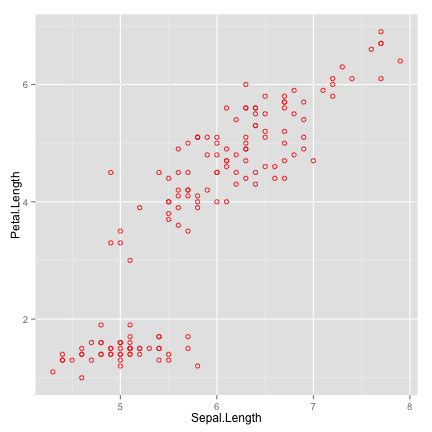

```r
require(ggplot2)
data(iris)
attach(iris)
p <- ggplot(iris, aes(Sepal.Length, Petal.Length)) + geom_point(shape = 1, color = "red")
print(p)
```

我们需要拟合： \[ Petal \approx \beta_0 + \beta_1 Sepal \]

\(\beta_0\) 和 \(\beta_1\) 代表线性模型的截距和斜率，这两个模型参数是未知的，需要通过训练数据估计 \(\hat{\beta_0}\) 和 \(\hat{\beta_1}\) 。

使得直线 \[ \hat{y} = \hat{\beta_0} + \hat{\beta_1} x \] 与数据集中的点最接近，有多种方法来来计算"接近度“，最常用的是最小二乘法(least squares)。

最小二乘法通过计算残差平方和（RSS, residual sum of squares） \[ RSS = {e_1}^2 + {e_2}^2 + … + {e_n}^2 \] 其中 \(e_i = y_i - \hat{y_i}\) . 问题转换为找出 \(\hat{\beta_0}\) 和 \(\hat{\beta_1}\) 使得RSS的值最小。 通过计算，可以得到： \[ \hat{\beta_1} = \frac{\sum_{i=1}^n (x_i - \bar{x})(y_i - \bar{y})}{\sum_{i=1}^n (x_i - \bar{x})^2} = r_{xy} (\frac{s_y}{s_x})\] \[ \hat{\beta_0} = \bar{y} - \hat{\beta_1}\bar{x} \]

```r
b1 <- sum((Petal.Length - mean(Petal.Length)) * (Sepal.Length - mean(Sepal.Length)))/sum((Sepal.Length -
    mean(Sepal.Length))^2)
b0 <- mean(Petal.Length) - b1 * mean(Sepal.Length)
cat("Intersect:\t", b0, "\n", "Slope:\t", b1, "\n")
```

```
## Intersect:    -7.101
##  Slope:   1.858
```

stats包中的lm()函数，用于拟合线性模型。

```r
model <- lm(Petal.Length ~ Sepal.Length, data = iris)
model
```

```
##
## Call:
## lm(formula = Petal.Length ~ Sepal.Length, data = iris)
##
## Coefficients:
##  (Intercept)  Sepal.Length
##        -7.10          1.86
```

## 评估参数准确性

打个比方，我们使用样本均值 \(\hat{\mu}\) 来估计总体均值 \(\mu\) ，对于任意一个样本的 \(\hat{\mu}\) 值，有可能会高估 \(\mu\) ，也有可能会低估，需要量化到底 \(\hat{\mu}\) 偏离 \(\mu\) 有多远，这个问题通过计算standard error of \(\hat{\mu}\) 来解决。

同样地，我们估计出来的参数 \(\hat{\beta_0}\) 和 \(\hat{\beta_1}\) 和真实的参数到底偏离多远，需要通过计算参数的standard error来估计。 \[ SE(\hat{\beta_0})^2 = \sigma^2 [\frac{1}{n} + \frac{\bar{x}^2}{\sum_{i=1}^n (x_i-\bar{x})^2}] \] \[ SE(\hat{\beta_1})^2 = \frac{\sigma^2}{\sum_{i=1}^n (x_i-\bar{x})^2} \]

其中 \(\sigma^2 = Var(\epsilon)\) ，通常情况下是未知的，使用残差标准误 \(RSE=\sqrt{RSS/(n-2)}\) 来估计。

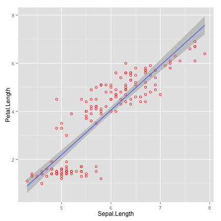

```r
p + geom_smooth(method = "lm", se = TRUE, level = 0.95)
```

上图中，阴影部分就是参数的95%置信区间。

有了标准误，还可以用统计检验来检测X和Y是否具有相关性。 在这里，可以使用t检验，计算t统计量： \[ t = \frac{\hat{\beta_1} - 0}{SE(\hat{\beta_1})} \]

这些统计量，lm()函数都会计算。

```r
summary(model)
```

```
##
## Call:
## lm(formula = Petal.Length ~ Sepal.Length, data = iris)
##
## Residuals:
##     Min      1Q  Median      3Q     Max
## -2.4775 -0.5907 -0.0067  0.6048  2.4951
##
## Coefficients:
##              Estimate Std. Error t value Pr(>|t|)
## (Intercept)   -7.1014     0.5067   -14.0   <2e-16 ***
## Sepal.Length   1.8584     0.0859    21.6   <2e-16 ***
## ---
## Signif. codes:  0 '***' 0.001 '**' 0.01 '*' 0.05 '.' 0.1 ' ' 1
##
## Residual standard error: 0.868 on 148 degrees of freedom
## Multiple R-squared:  0.76,   Adjusted R-squared:  0.758
## F-statistic:  469 on 1 and 148 DF,  p-value: <2e-16
```

## 评估模型准确性

### 残差标准误(RSE, residual standard error)

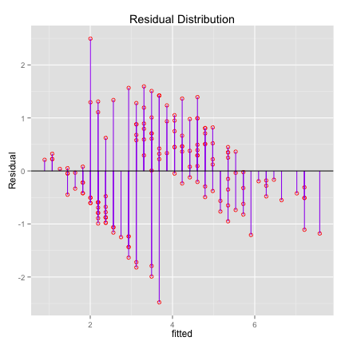

```r
iris$fitted <- predict(model)
p %+% iris + aes(x = fitted, y = Petal.Length - fitted) + geom_linerange(aes(ymin = 0,
    ymax = Petal.Length - fitted), colour = "purple") + geom_hline(aes(yintercept = 0)) +
    ggtitle("Residual Distribution") + ylab("Residual")
```

RSE是Y值和回归直线偏离值均值： \[ RSE = \sqrt{\frac{RSS}{n-2}} = \sqrt{\frac{\sum_{i=1}^n (y_i-\hat{y_i})^2}{n-2}} \]

```r
rse <- with(iris, sqrt(sum((fitted - Petal.Length)^2)/(length(Petal.Length) -
    2)))
print(rse)
```

```
## [1] 0.8678
```

通过RSE，可以计算模型预测值和真实值平均水平偏离多少。偏离量大不大，可以用 \(RSE/\bar{y}\) 来估计。

```r
with(iris, rse/mean(Petal.Length))
```

```
## [1] 0.2309
```

RSE度量的是失拟（lack of fit），如果RSE很小，则 \(\hat{y_i}\) 和 \(y_i\) 很接近，模型对数据的拟合非常好，如果RSE很大，则表明模型对数据的拟合很差。

### \(R^2\) 统计量

RSE是绝对值，不够清晰，用 \(RSE/\bar{y}\) 相对值会好一些。 \(R^2\) 提供另外一种度量方式: \[ R^2 = \frac{TSS - RSS}{TSS} = 1 - \frac{RSS}{TSS}\]

其中 \(TSS=\sum(y_i - \bar{y})^2\) ,TSS度量Y的方差，也就是拟合前总的方差；而RSS度量的是残差的方差，也就是拟合后无法解释的方差；TSS-RSS度量的是能够由拟合模型解释的方差；继而， \(R^2\) 统计量度量的是Y的方差能由X来解释的比例。

\(R^2\) 接近1，表明回归能解释Y的方差，回归模型拟合得好。而接近0的话，则表明无法解释Y的大部分方差，拟合模型很差，甚至可能是错的。

```r
tss <- with(iris, sum((Petal.Length - mean(Petal.Length))^2))
rss <- with(iris, sum((fitted - Petal.Length)^2))
rr <- 1 - rss/tss
rr
```

```
## [1] 0.76
```

\(R^2\) 统计量度量的是X和Y的线性相关性，我们知道相关系数r定义为： \[ Cor(X, Y) = \frac{\sum_{i=1}^n (x_i - \bar{x}) (y_i - \bar{y})}{\sqrt{\sum_{i=1}^n (x_i - \bar{x})^2)}\sqrt{\sum_{i=1}^n (y_i - \bar{y})^2)}}\]

同样我们可以用相关系数r来评估模型，事实上 \(R^2 = r^2\) ，可以说 \(R^2\) 是 \(r^2\) 的通用形式，相关系数只能用于单变量，如果要用多变量做线性回归的话，就没法用，从这个角度来看，也可以说 \(R^2\) 是 \(r^2\) 的扩展形式。

## 方差分析

如前所述，Y的方差TSS，由两部分组成，残差方差(RSS)和回归方差(TSS-RSS)，继而我们可以进行方差分析，TSS的自由度是n-1, 回归方差是1(简单线性回归是单变量),残差方差的自由度是n-2 （TSS的df - 回归方差df），将方差除以自由度，得到平均方差。

如果不存在线性关系，那么回归平均方差和残差平均方差大致相等。可以使用F统计量来检验是否存在线性关系。 \[ F = \frac{regression\; mean\; square}{residual\; mean\; square} = \frac{TSS-RSS}{RSS/(n-2)}\]

F统计量服从1和n-2自由度的F分析，继而可以计算出p值，当然可以直接扔给anova函数，进行统计计算。

```r
n <- nrow(iris)
fstat <- (tss - rss)/(rss/(n - 2))
print(fstat)
```

```
## [1] 468.6
```

```r
pf(fstat, 1, n - 2, lower.tail = F)
```

```
## [1] 1.039e-47
```

```r
anova(model)
```

```
## Analysis of Variance Table
##
## Response: Petal.Length
##               Df Sum Sq Mean Sq F value Pr(>F)
## Sepal.Length   1    353     353     469 <2e-16 ***
## Residuals    148    111       1
## ---
## Signif. codes:  0 '***' 0.001 '**' 0.01 '*' 0.05 '.' 0.1 ' ' 1
```

## 可视化辅助诊断模型

评估模型最重要的指标是残差，R提供了函数可视化残差，残差 vs 拟合值, 残差开方 vs 拟合值, 残差的QQ图，标准化残差 vs Leverage, [leverage度量的是数据点对回归线的影响](http://onlinestatbook.com/2/regression/influential.html)。

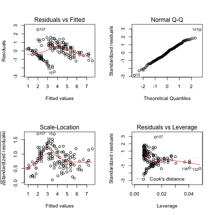

[output not shown]

```r
par(mfrow = c(2, 2))
plot(model)
```

## 欢迎请作者一杯咖啡

[figure not shown]

## 访问统计

[figure not shown]